# W7: Homework

Helene Andersen

20 July 2020, updated 01 November, 2020

# Goal

I want to be able to analyse the data from OECD on gender inequality. My focus will be on the share of female seats at the largest listed companies. Data from: https://stats.oecd.org/index.aspx?queryid=54753

# Solution

First, install a handful of classic R packages and load their libraries:

- `rvest` for web-scraping
- `dplyr` for data-wrangling
- `tidyr` for data transformation
- `stringr` for string manipulation
- `janitor` for clean headers that your OCD will love you for

```r
library(rvest)
library(dplyr)
library(tidyr)
library(stringr)
library(janitor)
```

## Scrape the data

Next, learn how scrape the content of the website and extract the HTML table:

```r
url <- "https://stats.oecd.org/index.aspx?queryid=54753"
# scrape the website
url_html <- read_html(url)
```

The data have to be cleaned before I can use it

```r
whole_table <- url_html %>%
 html_nodes("tr") %>% #en række (tr)
 html_text(trim = FALSE)
head(whole_table)
```

[output not shown]

I have to sort out the first lines of the table for it to make sense

```r
whole_table <- url_html %>%
 html_nodes("td") %>% #en individuel celle (td)
 html_text(trim = FALSE)
head(whole_table)
```

```
## [1] "Australia" ""          ".."        ".."        ".."        ".."
```

```r
whole_table <- url_html %>%
 html_nodes("table") %>%
 html_table(fill = TRUE)  #str(whole_table) turns out to be a list
```

If you run a `head()` on the resulting `whole_table`, you will see that it is a list with unnamed elements marked by numbers in double brackets, such as [[1]]. What is a list? A table-like looking structure that needs one more transformation (in this case, unlisting) before it becomes a useful dataframe.

```r
new_table <- do.call(cbind,unlist(whole_table, recursive = FALSE))
head(new_table)
```

```
##      Indicator   Indicator   Indicator
## [1,] "Age Group" "Age Group" "Age Group"
## [2,] "Unit"      "Unit"      "Unit"
## [3,] "Sex"       "Sex"       "Sex"
## [4,] "Time"      "Time"      "Time"
## [5,] "Time"      "Time"      "Time"
## [6,] "Time"      "Time"      "Time"
##      Female share of seats on boards of the largest publicly listed companies
## [1,] "Total"
## [2,] "Percentage"
## [3,] "Women"
## [4,] "2010"
## [5,] ""
## [6,] NA
##      Female share of seats on boards of the largest publicly listed companies
```

[output cut: 76 more lines]

Now I tidy the data by saying it should only count in the rows 8-51 nand the colomns 2-13

```r
femaleseats <- new_table[8:51,2:13] #chose the rows and columns I want to look at
femaleseats <- femaleseats[,c(1,3:12)] #chose the columns I want to eliminate/look at
colnames(femaleseats) <- c("Country", "2010", "2011", "2012", "2013", "2014", "2015", "2016", "2017", "2018", "2019")
```

Now I will make some visualization on my script

```r
fseats <- as_tibble(femaleseats)
```

```r
fseats %>%
    filter(Country== "Denmark")
```

```
## # A tibble: 1 x 11
##   Country `2010` `2011` `2012` `2013` `2014` `2015` `2016` `2017` `2018` `2019`
##   <chr>   <chr>  <chr>  <chr>  <chr>  <chr>  <chr>  <chr>  <chr>  <chr>  <chr>
## 1 Denmark 17.7   16.3   20.8   22.9   24.0   25.8   27.1   30.3   27.7   30.0
```

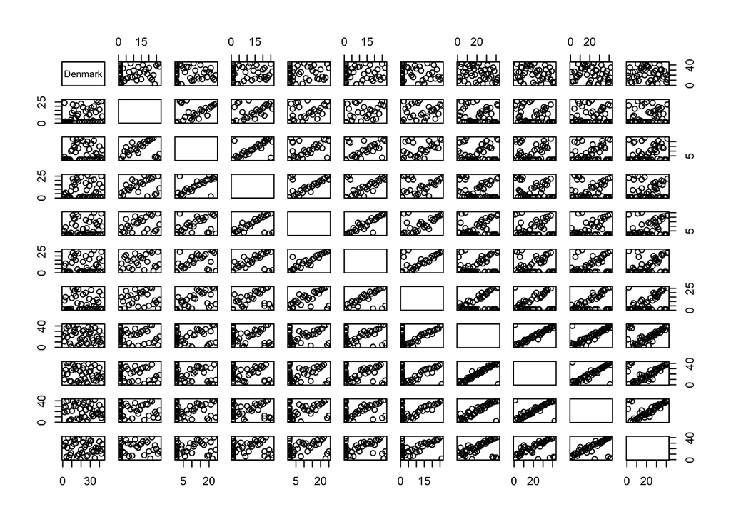

```r
plot(fseats, "Denmark")
```

This did not work as the visualization…. but I did not want to spend any more time on it!